# Lecture_03.ggplot2.p2.JupyterHub.live

## 6.0.0 Class summary

Today we have dug deep into altering and playing with our plots to help get them to that extra level. Although there is far more to explore, this should cover *most* of your needs when it comes to cleaning up your plots. Looking a little bit ahead at this week's assignment, you will look at canada-wide vaccination data.

You now have the tools to create plots like this:

[figure not shown]

and this:

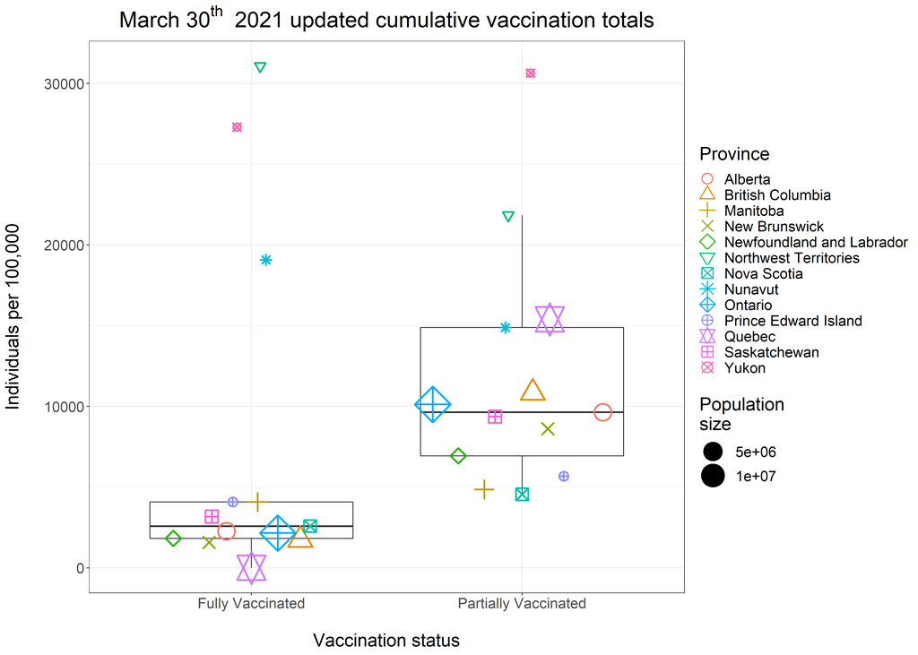

### I can't wait to revisit these graphs in a few months!

## 7.0.0 Weekly assignment

This week's assignment will be found under the current lecture folder under the "assignment" subfolder. It will include a Jupyter notebook that you will use to produce the code and answers for this week's assignment. Please provide answers in markdown or code cells that immediately follow each question section.

|  | Assignment breakdown |  |
| --- | --- | --- |
| Code | 50% | - Does it follow best practices? |
|  |  | - Does it make good use of available packages? |
|  |  | - Was data prepared properly |
| Answers and Output | 50% | - Is output based on the correct dataset? |
|  |  | - Are groupings appropriate |
|  |  | - Are correct titles/axes/legends correct? |
|  |  | - Is interpretation of the graphs correct? |

Since coding styles and solutions can differ, students are encouraged to use best practices. Assignments *may* be rewarded for well-coded or elegant solutions.

## 8.0.0 References

The R Graph Gallery: https://www.r-graph-gallery.com/index.html

Advanced examples of direct labeling with `geom_dl()`: https://directlabels.r-forge.r-project.org/examples.html

More information about the `gghighlight` package: https://cran.r-project.org/web/packages/gghighlight/vignettes/gghighlight.html

Using `expression()`: https://stat.ethz.ch/R-manual/R-devel/library/grDevices/html/plotmath.html

Using `bquote()`: https://www.r-bloggers.com/2018/03/math-notation-for-r-plot-titles-expression-and-bquote/

More options for `ggarrange()`: https://rpkgs.datanovia.com/ggpubr/reference/ggarrange.html